# supplemental_analyses

Author

Liam Doyle

## Supplementary Analyses: Addressing Potential Order Confound Effect

I will address the potential order confound effect in several ways. To begin with, I will start by subsetting each participant’s first five data points and their last five data points in the one-shot games and comparing them to determine their consistency. After that, I will use a paired samples *t*-test to determine if there is a significant difference between the mean defection rate/average payoff/relative payoff in the first half vs. the second half.

### Mean Scores

In the first code chunk, I will examine the mean defection rates in the first and second half.

```r
# Creating list of columns for mean scores

first_half <- paste0("OS", c(1:5))
second_half <- paste0("OS", c(6:10))

# Creating two new columns (i.e., first-half mean scores and second-half mean scores for OS games)

confound <- data %>%
  mutate(
    OS_Avg_1 = round(base::rowMeans(dplyr::select(., all_of(first_half)), na.rm = TRUE), 2),
    OS_Avg_2 = round(base::rowMeans(dplyr::select(., all_of(second_half)), na.rm = TRUE), 2
  ))

# Examining summary statistics of the two new variables

psych::describe(confound[, c("OS_Avg_1", "OS_Avg_2")])
```

```
         vars   n mean   sd median trimmed mad min max range  skew kurtosis
OS_Avg_1    1 364 0.46 0.27    0.4    0.45 0.3   0   1     1  0.23    -0.50
OS_Avg_2    2 364 0.60 0.27    0.6    0.61 0.3   0   1     1 -0.18    -0.67
           se
OS_Avg_1 0.01
OS_Avg_2 0.01
```

```r
# Using TOSTER to examine equivalence based on a raw difference of 0.05 (i.e., 5% difference in defection rate)

res_1 <- t_TOST(confound$OS_Avg_1,
       confound$OS_Avg_2,
       hypothesis = "MET",
       paired = TRUE,
       eqb = c(-.05, 0))

res_1
```

```
Paired t-test

The minimal effect test was significant, t(363) = -10, p < 0.01
The null hypothesis test was significant, t(363) = -10.4p < 0.01
NHST: reject null significance hypothesis that the effect is equal to zero
TOST: reject null MET hypothesis

TOST Results
                 t  df p.value
t-test     -10.376 363 < 0.001
TOST Lower  -6.673 363 < 0.001
TOST Upper -10.376 363       1

Effect Sizes
              Estimate      SE               C.I. Conf. Level
Raw            -0.1401 0.01350 [-0.1624, -0.1178]         0.9
Hedges's g(z)  -0.5427 0.05617 [-0.6346, -0.4502]         0.9
Note: SMD confidence intervals are an approximation. See vignette("SMD_calcs").
```

```r
TOSTER::describe(res_1)
```

```
[1] "Using the Paired t-test, a null hypothesis significance test (NHST), and a minimal effect test, via two one-sided tests (TOST), were performed with an alpha-level of 0.05. These tested the null hypotheses that true mean difference is equal to 0 (NHST), and true mean difference is greater than -…
```

```
SMD cannot be plotted if type = "tnull"
```

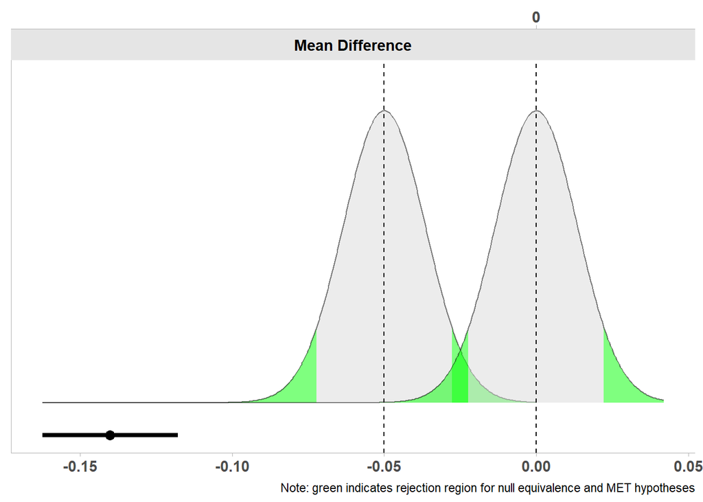

```r
plot(res_1, type = "tnull")
```

In the second code chunk, I will examine the means for average payoffs in the first and second half of OS trials.

```r
# Creating list of columns for mean scores

first_half <- paste0("OSF", c(1:5))
second_half <- paste0("OSF", c(6:10))

# Creating two new columns (i.e., first-half average payoff and second-half average payoff for OS games)

confound <- confound %>%
  mutate(
    OSF_Avg_1 = round(base::rowMeans(dplyr::select(., all_of(first_half)), na.rm = TRUE), 2),
    OSF_Avg_2 = round(base::rowMeans(dplyr::select(., all_of(second_half)), na.rm = TRUE), 2
  ))

# Examining summary statistics of the two new variables

psych::describe(confound[, c("OSF_Avg_1", "OSF_Avg_2")])
```

```
          vars   n  mean   sd median trimmed  mad min max range  skew kurtosis
OSF_Avg_1    1 364  9.84 3.61     10    9.90 2.97   0  19    19 -0.15    -0.01
OSF_Avg_2    2 364 10.34 3.72     10   10.34 2.97   1  20    19  0.06    -0.26
            se
OSF_Avg_1 0.19
OSF_Avg_2 0.19
```

```r
# Using TOSTER to examine equivalence based on a raw difference of 1 point in payoffs (i.e., 5% difference in exploitative behavior)

res_2 <- t_TOST(confound$OSF_Avg_1,
       confound$OSF_Avg_2,
       hypothesis = "MET",
       paired = TRUE,
       eqb = c(0, -1))

res_2
```

```
Paired t-test

The minimal effect test was non-significant, t(363) = -2, p = 0.97
The null hypothesis test was significant, t(363) = -1.98p = 0.05
NHST: reject null significance hypothesis that the effect is equal to zero
TOST: don't reject null MET hypothesis

TOST Results
                t  df p.value
t-test     -1.982 363   0.048
TOST Lower  1.960 363   0.975
TOST Upper -1.982 363   0.976

Effect Sizes
              Estimate      SE               C.I. Conf. Level
Raw            -0.5027 0.25365  [-0.921, -0.0845]         0.9
Hedges's g(z)  -0.1037 0.05256 [-0.1899, -0.0173]         0.9
Note: SMD confidence intervals are an approximation. See vignette("SMD_calcs").
```

```r
TOSTER::describe(res_2)
```

```
[1] "Using the Paired t-test, a null hypothesis significance test (NHST), and a minimal effect test, via two one-sided tests (TOST), were performed with an alpha-level of 0.05. These tested the null hypotheses that true mean difference is equal to 0 (NHST), and true mean difference is greater than -…
```

```
SMD cannot be plotted if type = "tnull"
```

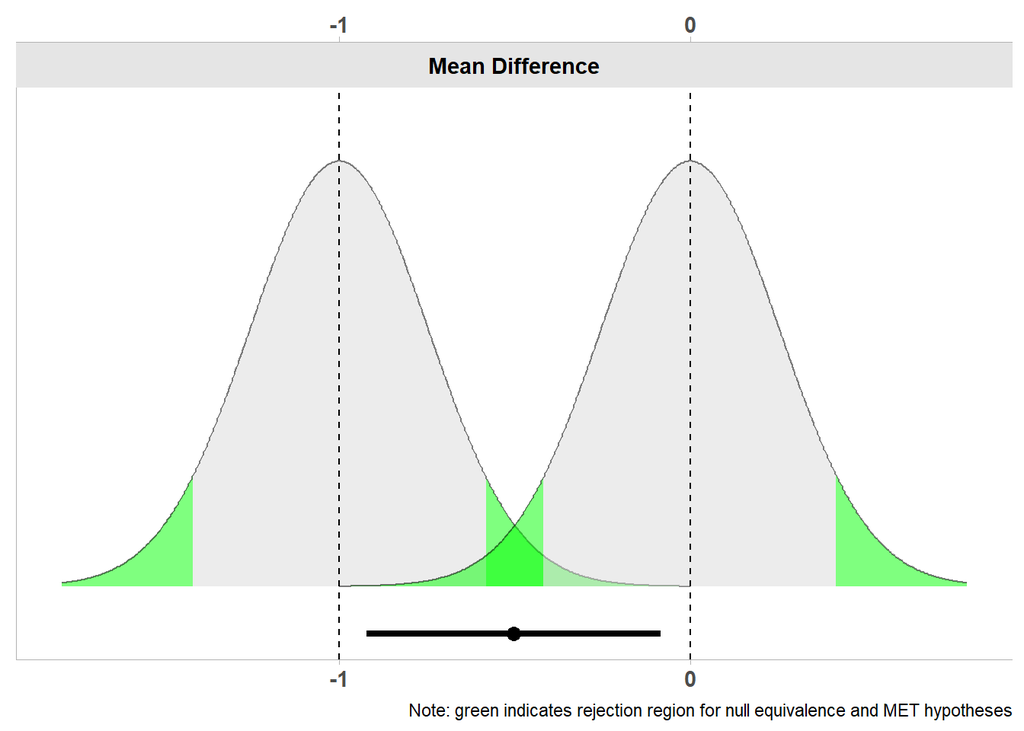

```r
plot(res_2, type = "tnull")
```

In the third code chunk, I will examine the means for relative payoffs in the first and second half of OS trials.

```r
# Creating list of columns for mean scores

first_half <- paste0("Diff_OSF", c(1:5))
second_half <- paste0("Diff_OSF", c(6:10))

# Creating two new columns (i.e., first-half mean scores and second-half mean scores for OS games)

confound <- confound %>%
  mutate(
    Diff_OSF_Avg_1 = round(base::rowMeans(dplyr::select(., all_of(first_half)), na.rm = TRUE), 2),
    Diff_OSF_Avg_2 = round(base::rowMeans(dplyr::select(., all_of(second_half)), na.rm = TRUE), 2
  ))

# Examining summary statistics of the two new variables

psych::describe(confound[, c("Diff_OSF_Avg_1", "Diff_OSF_Avg_2")])
```

```
               vars   n  mean   sd median trimmed  mad min max range  skew
Diff_OSF_Avg_1    1 364 -0.81 7.13      0   -0.74 5.93 -20  16    36 -0.06
Diff_OSF_Avg_2    2 364  1.73 7.07      0    1.66 5.93 -16  20    36  0.05
               kurtosis   se
Diff_OSF_Avg_1    -0.18 0.37
Diff_OSF_Avg_2    -0.13 0.37
```

```r
# Using TOSTER to examine equivalence based on a raw difference of 1 point in payoffs (i.e., 5% difference in exploitative behavior)

res_3 <- t_TOST(confound$Diff_OSF_Avg_1,
       confound$Diff_OSF_Avg_2,
       hypothesis = "MET",
       paired = TRUE,
       eqb = 1)

res_3
```

```
Paired t-test

The minimal effect test was significant, t(363) = -8.4, p < 0.01
The null hypothesis test was significant, t(363) = -6.01p < 0.01
NHST: reject null significance hypothesis that the effect is equal to zero
TOST: reject null MET hypothesis

TOST Results
                t  df p.value
t-test     -6.008 363 < 0.001
TOST Lower -3.641 363 < 0.001
TOST Upper -8.374 363       1

Effect Sizes
              Estimate     SE               C.I. Conf. Level
Raw            -2.5385 0.4225 [-3.2353, -1.8417]         0.9
Hedges's g(z)  -0.3142 0.0537 [-0.4022, -0.2259]         0.9
Note: SMD confidence intervals are an approximation. See vignette("SMD_calcs").
```

```r
TOSTER::describe(res_3)
```

```
[1] "Using the Paired t-test, a null hypothesis significance test (NHST), and a minimal effect test, via two one-sided tests (TOST), were performed with an alpha-level of 0.05. These tested the null hypotheses that true mean difference is equal to 0 (NHST), and true mean difference is greater than -…
```

```
SMD cannot be plotted if type = "tnull"
```

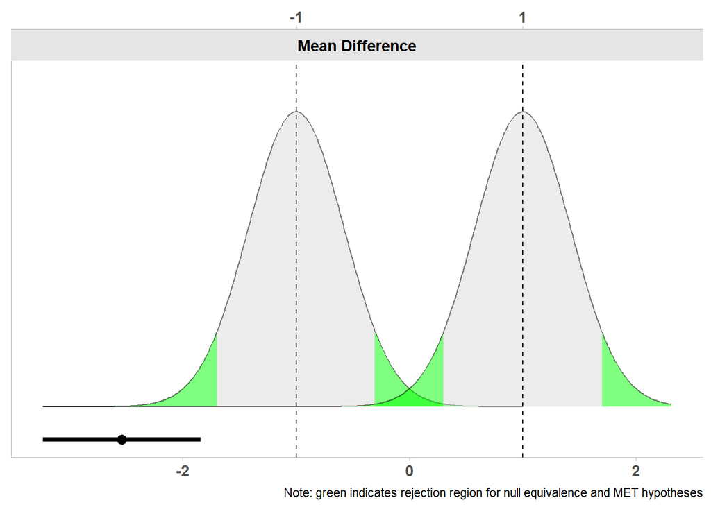

```r
plot(res_3, type = "tnull")
```

### Correlations

The second way that I will examine the potential order confound is by examining (a) the correlations between psychopathy and the two new variables and (b) examining the correlations between the two new variables and the iterated variable. In the first code chunk, I will examine the defection rates.

```r
# Setting seed

set.seed(123)

# Examining correlation between psychopathy and first/second half OS defection rates

pbcor(confound$OS_Avg_1, confound$SRP_Total, ci = TRUE, nboot = 1000)
```

```
Call:
pbcor(x = confound$OS_Avg_1, y = confound$SRP_Total, ci = TRUE,
    nboot = 1000)

Robust correlation coefficient: 0.109
Test statistic: 2.0863
p-value: 0.03765

Bootstrap CI: [0.0081; 0.2061]
```

```r
pbcor(confound$OS_Avg_2, confound$SRP_Total, ci = TRUE, nboot = 1000)
```

```
Call:
pbcor(x = confound$OS_Avg_2, y = confound$SRP_Total, ci = TRUE,
    nboot = 1000)

Robust correlation coefficient: 0.1269
Test statistic: 2.4337
p-value: 0.01543

Bootstrap CI: [0.0285; 0.2162]
```

```r
# Comparing first and second half correlations w/ psychopathy using TOSTER (r1 = .109, r2 = .1269)

boot_cor_test(confound$OS_Avg_2,
              confound$SRP_Total,
              alternative = "greater",
              method = "bend",
              null = .109
              )
```

```
    Bootstrapped percentage bend correlation pb

data:  confound$OS_Avg_2 and confound$SRP_Total
N = 364, p-value = 0.3617
alternative hypothesis: true pb is greater than 0.109
90 percent confidence interval:
 0.04134184 0.21437591
sample estimates:
       pb
0.1268782
```

```r
# Examining correlation between iterated defection rates and first/second half OS defection rates

pbcor(confound$OS_Avg_1, confound$IT_Avg, ci = TRUE, nboot = 1000)
```

```
Call:
pbcor(x = confound$OS_Avg_1, y = confound$IT_Avg, ci = TRUE,
    nboot = 1000)

Robust correlation coefficient: 0.4876
Test statistic: 10.6257
p-value: 0

Bootstrap CI: [0.3925; 0.5755]
```

```r
pbcor(confound$OS_Avg_2, confound$IT_Avg, ci = TRUE, nboot = 1000)
```

```
Call:
pbcor(x = confound$OS_Avg_2, y = confound$IT_Avg, ci = TRUE,
    nboot = 1000)

Robust correlation coefficient: 0.5143
Test statistic: 11.4098
p-value: 0

Bootstrap CI: [0.4127; 0.6014]
```

```r
# Comparing first and second correlations using TOSTER (r1 = .4876, r2 = .5143)

boot_cor_test(confound$OS_Avg_2,
              confound$IT_Avg,
              alternative = "greater",
              method = "bend",
              null = .4876
              )
```

```
    Bootstrapped percentage bend correlation pb

data:  confound$OS_Avg_2 and confound$IT_Avg
N = 364, p-value = 0.2671
alternative hypothesis: true pb is greater than 0.4876
90 percent confidence interval:
 0.4386024 0.5915116
sample estimates:
      pb
0.514298
```

In the second code chunk, I will examine the correlations with the average payoffs.

```r
# Setting seed

set.seed(123)

# Examining correlation between psychopathy and first/second half OS average payoffs

pbcor(confound$OSF_Avg_1, confound$SRP_Total, ci = TRUE, nboot = 1000)
```

```
Call:
pbcor(x = confound$OSF_Avg_1, y = confound$SRP_Total, ci = TRUE,
    nboot = 1000)

Robust correlation coefficient: -0.0054
Test statistic: -0.1025
p-value: 0.9184

Bootstrap CI: [-0.1245; 0.106]
```

```r
pbcor(confound$OSF_Avg_2, confound$SRP_Total, ci = TRUE, nboot = 1000)
```

```
Call:
pbcor(x = confound$OSF_Avg_2, y = confound$SRP_Total, ci = TRUE,
    nboot = 1000)

Robust correlation coefficient: 0.1478
Test statistic: 2.8437
p-value: 0.00471

Bootstrap CI: [0.0473; 0.2426]
```

```r
# Comparing first and second half correlations w/ psychopathy using TOSTER (r1 = -.005, r2 = .148)

boot_cor_test(confound$OSF_Avg_2,
              confound$SRP_Total,
              alternative = "greater",
              method = "bend",
              null = -.005
              )
```

```
    Bootstrapped percentage bend correlation pb

data:  confound$OSF_Avg_2 and confound$SRP_Total
N = 364, p-value = 0.002501
alternative hypothesis: true pb is greater than -0.005
90 percent confidence interval:
 0.06688031 0.23420702
sample estimates:
       pb
0.1478203
```

```r
# Examining correlation between iterated average payoffs and first/second half OS average payoffs

pbcor(confound$OSF_Avg_1, confound$ITF_Avg, ci = TRUE, nboot = 1000)
```

```
Call:
pbcor(x = confound$OSF_Avg_1, y = confound$ITF_Avg, ci = TRUE,
    nboot = 1000)

Robust correlation coefficient: -0.2478
Test statistic: -4.867
p-value: 0

Bootstrap CI: [-0.3624; -0.1464]
```

```r
pbcor(confound$OSF_Avg_2, confound$ITF_Avg, ci = TRUE, nboot = 1000)
```

```
Call:
pbcor(x = confound$OSF_Avg_2, y = confound$ITF_Avg, ci = TRUE,
    nboot = 1000)

Robust correlation coefficient: -0.1546
Test statistic: -2.9775
p-value: 0.0031

Bootstrap CI: [-0.2576; -0.0497]
```

```r
# Comparing first and second correlations using TOSTER (r1 = -.248, r2 = -.155)

boot_cor_test(confound$OSF_Avg_2,
              confound$ITF_Avg,
              alternative = "less",
              method = "bend",
              null = -.248
              )
```

```
    Bootstrapped percentage bend correlation pb

data:  confound$OSF_Avg_2 and confound$ITF_Avg
N = 364, p-value = 0.96
alternative hypothesis: true pb is less than -0.248
90 percent confidence interval:
 -0.2391882 -0.0673129
sample estimates:
        pb
-0.1546144
```

In the third code chunk, I will examine the correlations with the relative payoffs.

```r
# Setting seed

set.seed(123)

# Examining correlation between psychopathy and first/second half OS relative payoffs

pbcor(confound$Diff_OSF_Avg_1, confound$SRP_Total, ci = TRUE, nboot = 1000)
```

```
Call:
pbcor(x = confound$Diff_OSF_Avg_1, y = confound$SRP_Total, ci = TRUE,
    nboot = 1000)

Robust correlation coefficient: 0.0468
Test statistic: 0.8908
p-value: 0.37363

Bootstrap CI: [-0.0586; 0.148]
```

```r
pbcor(confound$Diff_OSF_Avg_2, confound$SRP_Total, ci = TRUE, nboot = 1000)
```

```
Call:
pbcor(x = confound$Diff_OSF_Avg_2, y = confound$SRP_Total, ci = TRUE,
    nboot = 1000)

Robust correlation coefficient: 0.1624
Test statistic: 3.1315
p-value: 0.00188

Bootstrap CI: [0.0587; 0.2606]
```

```r
# Comparing first and second half correlations w/ psychopathy using TOSTER (r1 = .047, r2 = .162)

boot_cor_test(confound$Diff_OSF_Avg_2,
              confound$SRP_Total,
              alternative = "greater",
              method = "bend",
              null = .047
              )
```

```
    Bootstrapped percentage bend correlation pb

data:  confound$Diff_OSF_Avg_2 and confound$SRP_Total
N = 364, p-value = 0.01701
alternative hypothesis: true pb is greater than 0.047
90 percent confidence interval:
 0.07623718 0.24945694
sample estimates:
       pb
0.1624005
```

```r
# Examining correlation between iterated relative payoffs and first/second half OS relative payoffs

pbcor(confound$Diff_OSF_Avg_1, confound$Diff_IT_Avg, ci = TRUE, nboot = 1000)
```

```
Call:
pbcor(x = confound$Diff_OSF_Avg_1, y = confound$Diff_IT_Avg,
    ci = TRUE, nboot = 1000)

Robust correlation coefficient: 0.2626
Test statistic: 5.1778
p-value: 0

Bootstrap CI: [0.17; 0.3629]
```

```r
pbcor(confound$Diff_OSF_Avg_2, confound$Diff_IT_Avg, ci = TRUE, nboot = 1000)
```

```
Call:
pbcor(x = confound$Diff_OSF_Avg_2, y = confound$Diff_IT_Avg,
    ci = TRUE, nboot = 1000)

Robust correlation coefficient: 0.3225
Test statistic: 6.4826
p-value: 0

Bootstrap CI: [0.231; 0.4152]
```

```r
# Comparing first and second correlations using TOSTER (r1 = .263, r2 = .323)

boot_cor_test(confound$Diff_OSF_Avg_2,
              confound$Diff_IT_Avg,
              alternative = "greater",
              method = "bend",
              null = .263
              )
```

```
    Bootstrapped percentage bend correlation pb

data:  confound$Diff_OSF_Avg_2 and confound$Diff_IT_Avg
N = 364, p-value = 0.1146
alternative hypothesis: true pb is greater than 0.263
90 percent confidence interval:
 0.244778 0.402603
sample estimates:
       pb
0.3225125
```

### Linear Mixed-Effects Models

The final (and most important way) that I will examine the potential order confound is by examining the parameters for each linear mixed-effects model, reconstructed so that actions/payoffs in one-shot games are represented by either (a) the first five interactions or (b) the second five interactions. There does not exist a package for the statistical comparison of linear mixed effects model coefficients, and I lack the mathematical training to construct the appropriate functions to do so. As such, comparison of parameters will be done manually.

In the first model, I will examine the potential order effect by examining a linear mixed effects model predicting defection rates from psychopathy scores and game type (OS first half, OS second half, and Iterated).

```r
# Creating list of columns for mean scores

first_half <- paste0("OS", c(1:5))
second_half <- paste0("OS", c(6:10))

# Creating two new columns (i.e., first-half mean scores and second-half mean scores for OS games)

confound <- data %>%
  mutate(
    OS_Avg_1 = round(base::rowMeans(dplyr::select(., all_of(first_half)), na.rm = TRUE), 2),
    OS_Avg_2 = round(base::rowMeans(dplyr::select(., all_of(second_half)), na.rm = TRUE), 2
  ))

# Step 1: Select the relevant columns, including 'mean_second_half'

filtered_data_confound <- confound %>%
  dplyr::select(Participant_ID, SRP_Total, OS_Avg_1, OS_Avg_2, IT_Avg)

# Step 2: Pivot data to long format

long_data <- pivot_longer(
  filtered_data_confound,
  cols = c("OS_Avg_1", "OS_Avg_2", "IT_Avg"),
  names_to = "Game_Type",
  values_to = "Decision"
)

# Step 3: Recode 'Game_Type' to 0 for one-shot (mean_first_half), 1 for iterated (IT_Avg), and 2 for second-half one-shot (mean_second_half)

long_data <- long_data %>%
  mutate(Game_Type = case_when(
    Game_Type == "OS_Avg_1" ~ 0,
    Game_Type == "OS_Avg_2" ~ 2,
    Game_Type == "IT_Avg" ~ 1,
    TRUE ~ as.integer(NA)
  ))

# Step 4: Convert 'Game_Type' to a factor with appropriate labels

long_data <- long_data %>%
  mutate(Game_Type = factor(Game_Type,
                            levels = c(0, 1, 2),
                            labels = c("One-Shot First Half", "Iterated",
                                       "One-Shot Second Half")))

# Linear mixed model with 'Game_Type' as a factor (including both one-shot halves and iterated games)
model <- lmer(Decision ~ SRP_Total * Game_Type + (1 | Participant_ID), data = long_data)

# Create APA style table with additional parameters (see sjPlot documentation)

tab_model(
  model,
  show.std = "std"
)
```

|  | Decision |  |  |  |  |  |
| --- | --- | --- | --- | --- | --- | --- |
| Predictors | Estimates | std. Beta | CI | standardized CI | p | std. p |
| (Intercept) | 0.32 | -0.23 | 0.17 – 0.47 | -0.33 – -0.13 | **<0.001** | **<0.001** |
| SRP Total | 0.06 | 0.10 | -0.00 – 0.13 | -0.01 – 0.20 | 0.064 | 0.064 |
| Game Type [Iterated] | 0.07 | 0.23 | -0.08 – 0.21 | 0.13 – 0.33 | 0.362 | **<0.001** |
| Game Type [One-Shot Second Half] | 0.15 | 0.46 | 0.00 – 0.29 | 0.36 – 0.56 | **0.045** | **<0.001** |
| SRP Total × Game Type [Iterated] | 0.00 | 0.00 | -0.06 – 0.07 | -0.10 – 0.10 | 0.984 | 0.984 |
| SRP Total × Game Type [One-Shot Second Half] | -0.00 | -0.01 | -0.07 – 0.06 | -0.11 – 0.09 | 0.913 | 0.913 |
| Random Effects |  |  |  |  |  |  |
| σ<sup>2</sup> | 0.04 |  |  |  |  |  |
| τ<sub>00</sub> <sub>Participant_ID</sub> | 0.04 |  |  |  |  |  |
| ICC | 0.51 |  |  |  |  |  |
| N <sub>Participant_ID</sub> | 364 |  |  |  |  |  |
| Observations | 1092 |  |  |  |  |  |
| Marginal R<sup>2</sup> / Conditional R<sup>2</sup> | 0.044 / 0.530 |  |  |  |  |  |

```r
# Examine marginal means

test_predictions(model,
                 c("SRP_Total", "Game_Type"),
                 test = NULL)
```

```
# (Average) Linear trend for SRP_Total

Game_Type            | Slope |      95% CI |     p
--------------------------------------------------
One-Shot First Half  |  0.06 |  0.00, 0.13 | 0.064
Iterated             |  0.06 |  0.00, 0.13 | 0.061
One-Shot Second Half |  0.06 | -0.01, 0.12 | 0.081
```

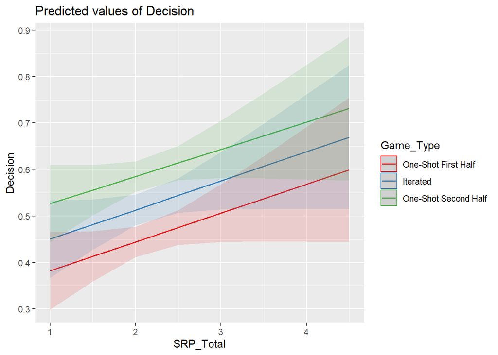

```r
plot_model(model,
           type = "int")
```

In the second model, I will examine the potential order effect by examining a linear mixed effects model predicting average payoffs from psychopathy scores and game type (OS first half, OS second half, and Iterated).

```r
# Creating list of columns for mean scores

first_half <- paste0("OSF", c(1:5))
second_half <- paste0("OSF", c(6:10))

# Creating two new columns (i.e., first-half mean scores and second-half mean scores for OS games)

confound <- data %>%
  mutate(
    OSF_Avg_1 = round(base::rowMeans(dplyr::select(., all_of(first_half)), na.rm = TRUE), 2),
    OSF_Avg_2 = round(base::rowMeans(dplyr::select(., all_of(second_half)), na.rm = TRUE), 2
  ))

# Step 1: Select the relevant columns, including 'mean_second_half'

filtered_data_confound <- confound %>%
  dplyr::select(Participant_ID, SRP_Total, OSF_Avg_1, OSF_Avg_2, ITF_Avg)

# Step 2: Pivot data to long format

long_data <- pivot_longer(
  filtered_data_confound,
  cols = c("OSF_Avg_1", "OSF_Avg_2", "ITF_Avg"),
  names_to = "Game_Type",
  values_to = "Average_Payoff"
)

# Step 3: Recode 'Game_Type' to 0 for one-shot (mean_first_half), 1 for iterated (IT_Avg), and 2 for second-half one-shot (mean_second_half)

long_data <- long_data %>%
  mutate(Game_Type = case_when(
    Game_Type == "OSF_Avg_1" ~ 0,
    Game_Type == "OSF_Avg_2" ~ 2,
    Game_Type == "ITF_Avg" ~ 1,
    TRUE ~ as.integer(NA)
  ))

# Step 4: Convert 'Game_Type' to a factor with appropriate labels

long_data <- long_data %>%
  mutate(Game_Type = factor(Game_Type,
                            levels = c(0, 1, 2),
                            labels = c("One-shot First Half", "Iterated",
                                       "One-shot Second Half")))

# Linear mixed model with 'Game_Type' as a factor (including both one-shot halves and iterated games)
model <- lmer(Average_Payoff ~ SRP_Total * Game_Type + (1 | Participant_ID), data = long_data)
```

```
boundary (singular) fit: see help('isSingular')
```

```r
# Create APA style table with additional parameters (see sjPlot documentation)

tab_model(
  model,
  show.std = "std"
)
```

```
boundary (singular) fit: see help('isSingular')
```

|  | Average_Payoff |  |  |  |  |  |
| --- | --- | --- | --- | --- | --- | --- |
| Predictors | Estimates | std. Beta | CI | standardized CI | p | std. p |
| (Intercept) | 9.97 | -0.12 | 8.29 – 11.65 | -0.23 – -0.02 | **<0.001** | **0.017** |
| SRP Total | -0.06 | -0.01 | -0.82 – 0.69 | -0.11 – 0.09 | 0.872 | 0.872 |
| Game Type [Iterated] | 1.85 | 0.23 | -0.53 – 4.23 | 0.08 – 0.37 | 0.127 | **0.002** |
| Game Type [One-shot Second Half] | -1.77 | 0.15 | -4.15 – 0.61 | 0.00 – 0.29 | 0.144 | **0.048** |
| SRP Total × Game Type [Iterated] | -0.49 | -0.07 | -1.56 – 0.57 | -0.21 – 0.08 | 0.364 | 0.364 |
| SRP Total × Game Type [One-shot Second Half] | 1.04 | 0.14 | -0.02 – 2.11 | -0.00 – 0.29 | 0.055 | 0.055 |
| Random Effects |  |  |  |  |  |  |
| σ<sup>2</sup> | 11.70 |  |  |  |  |  |
| τ<sub>00</sub> <sub>Participant_ID</sub> | 0.00 |  |  |  |  |  |
| N <sub>Participant_ID</sub> | 364 |  |  |  |  |  |
| Observations | 1092 |  |  |  |  |  |
| Marginal R<sup>2</sup> / Conditional R<sup>2</sup> | 0.016 / NA |  |  |  |  |  |

```r
# Examine marginal means

test_predictions(model,
                 c("SRP_Total", "Game_Type"),
                 test = NULL)
```

```
# (Average) Linear trend for SRP_Total

Game_Type            | Slope |      95% CI |     p
--------------------------------------------------
One-shot First Half  | -0.06 | -0.82, 0.69 | 0.872
Iterated             | -0.56 | -1.31, 0.20 | 0.149
One-shot Second Half |  0.98 |  0.23, 1.74 | 0.011
```

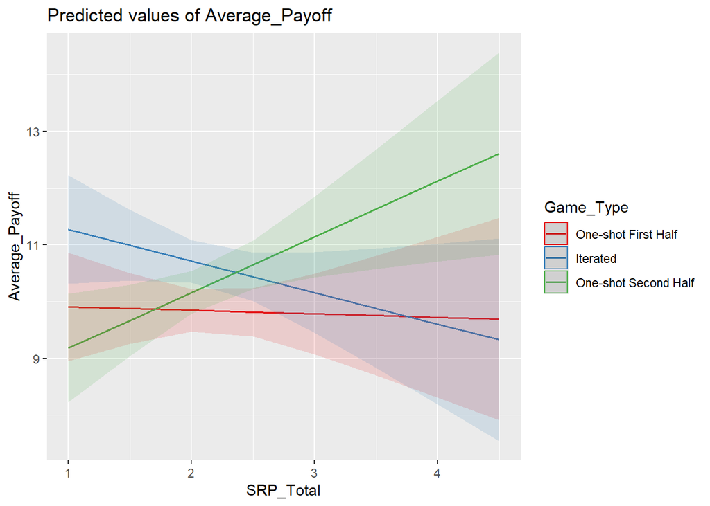

```r
plot_model(model,
           type = "int")
```

In the third model, I will examine the potential order effect by examining a linear mixed effects model predicting relative payoffs (i.e., difference scores) from psychopathy scores and game type (OS first half, OS second half, and Iterated).

```r
# Creating list of columns for mean scores

first_half <- paste0("Diff_OSF", c(1:5))
second_half <- paste0("Diff_OSF", c(6:10))

# Creating two new columns (i.e., first-half mean scores and second-half mean scores for OS games)

confound <- data %>%
  mutate(
    Diff_OSF_Avg_1 = round(base::rowMeans(dplyr::select(., all_of(first_half)), na.rm = TRUE), 2),
    Diff_OSF_Avg_2 = round(base::rowMeans(dplyr::select(., all_of(second_half)), na.rm = TRUE), 2
  ))

# Step 1: Select the relevant columns, including 'mean_second_half'

filtered_data_confound <- confound %>%
  dplyr::select(Participant_ID, SRP_Total, Diff_OSF_Avg_1, Diff_OSF_Avg_2, Diff_IT_Avg)

# Step 2: Pivot data to long format

long_data <- pivot_longer(
  filtered_data_confound,
  cols = c("Diff_OSF_Avg_1", "Diff_OSF_Avg_2", "Diff_IT_Avg"),
  names_to = "Game_Type",
  values_to = "Relative_Payoff"
)

# Step 3: Recode 'Game_Type' to 0 for one-shot (mean_first_half), 1 for iterated (IT_Avg), and 2 for second-half one-shot (mean_second_half)

long_data <- long_data %>%
  mutate(Game_Type = case_when(
    Game_Type == "Diff_OSF_Avg_1" ~ 0,
    Game_Type == "Diff_OSF_Avg_2" ~ 2,
    Game_Type == "Diff_IT_Avg" ~ 1,
    TRUE ~ as.integer(NA)
  ))

# Step 4: Convert 'Game_Type' to a factor with appropriate labels

long_data <- long_data %>%
  mutate(Game_Type = factor(Game_Type,
                            levels = c(0, 1, 2),
                            labels = c("OS First Half", "Iterated",
                                       "OS Second Half")))

# Linear mixed model with 'Game_Type' as a factor (including both one-shot halves and iterated games)
model <- lmer(Relative_Payoff ~ SRP_Total * Game_Type + (1 | Participant_ID), data = long_data)

# Create APA style table with additional parameters (see sjPlot documentation)

tab_model(
  model,
  show.std = "std"
)
```

|  | Relative_Payoff |  |  |  |  |  |
| --- | --- | --- | --- | --- | --- | --- |
| Predictors | Estimates | std. Beta | CI | standardized CI | p | std. p |
| (Intercept) | -2.44 | -0.25 | -5.29 – 0.42 | -0.35 – -0.15 | 0.094 | **<0.001** |
| SRP Total | 0.74 | 0.06 | -0.54 – 2.02 | -0.04 – 0.16 | 0.254 | 0.254 |
| Game Type [Iterated] | 3.36 | 0.33 | -0.21 – 6.94 | 0.20 – 0.46 | 0.065 | **<0.001** |
| Game Type [OS Second Half] | -0.39 | 0.43 | -3.96 – 3.19 | 0.30 – 0.55 | 0.831 | **<0.001** |
| SRP Total × Game Type [Iterated] | -0.64 | -0.05 | -2.25 – 0.96 | -0.18 – 0.08 | 0.431 | 0.431 |
| SRP Total × Game Type [OS Second Half] | 1.34 | 0.11 | -0.26 – 2.95 | -0.02 – 0.23 | 0.101 | 0.101 |
| Random Effects |  |  |  |  |  |  |
| σ<sup>2</sup> | 26.42 |  |  |  |  |  |
| τ<sub>00</sub> <sub>Participant_ID</sub> | 7.26 |  |  |  |  |  |
| ICC | 0.22 |  |  |  |  |  |
| N <sub>Participant_ID</sub> | 364 |  |  |  |  |  |
| Observations | 1092 |  |  |  |  |  |
| Marginal R<sup>2</sup> / Conditional R<sup>2</sup> | 0.044 / 0.250 |  |  |  |  |  |

```r
# Examine marginal means

test_predictions(model,
                 c("SRP_Total", "Game_Type"),
                 test = NULL)
```

```
# (Average) Linear trend for SRP_Total

Game_Type      | Slope |      95% CI |     p
--------------------------------------------
OS First Half  |  0.74 | -0.54, 2.02 | 0.254
Iterated       |  0.10 | -1.18, 1.38 | 0.878
OS Second Half |  2.09 |  0.81, 3.37 | 0.001
```

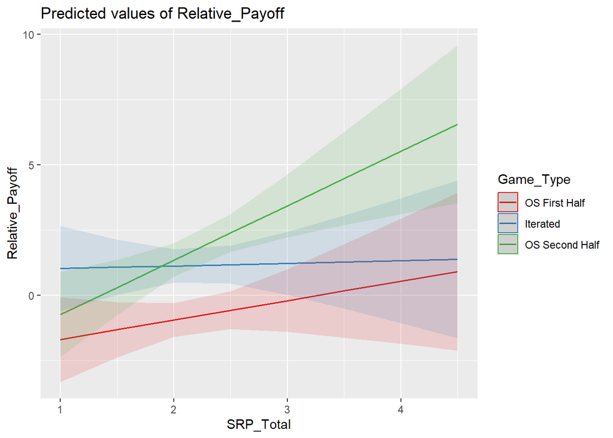

```r
plot_model(model,
           type = "int")
```